# Tutorial - Descriptive Statistics - HTML answer key

Christian Bowers

2023-10-04

## Descriptive Statistics, Histograms, and Boxplots

This tutorial will guide you through the process of making unique data sets for each of your students and a corresponding answer key. We begin with descriptive statistics. We will use the “fhs sample.csv” data set for this example.

First, create a folder to work in. Save your “fhs sample.csv” data set to that folder. Within this folder create another folder for the data sets you will output. Call it “Data - FHS”.

Open up RStudio and create a new R Markdown file.

[figure not shown]

Enter “FHS - answer key” for the title, and fill out the author and date. The “Default Output Format” should be set to HTML. If not, then select HTML. This will give us the best looking results and does not require any additional packages installed.

Since our students will be using jamovi, we need to load the jamovi library so our answer key will match their output.

If you have not installed the jamovi package, then do so by selecting

“Tools -> Install Packages…”

[figure not shown]

and in the “Packages” field, type “jmv”.

Then press “Install”.

Once you have completed the installation of the jmv package, you will not have to do that again.

Go to your R Markdown file. Notice that the title, author, date, and output block appears at the top. Below that, you see a gray box with the following:

knitr::opts_chunk$set(echo = TRUE)

[figure not shown]

Change “echo = TRUE” to “echo = FALSE”

This will prevent your code from printing out in the answer key.

Then, delete everything you see below the first gray box. That is there as an example. We will not need it.

[figure not shown]

Next, insert a new R code chunk.

[figure not shown]

You will paste and modify the lines of code from this tutorial inside of this R code chunk.

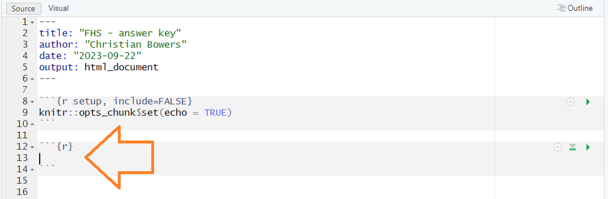

First, set the digits displayed to 4 and load the jamovi library by using the library() function.

```r
options(digits=4)
library(jmv)
```

Read our “fhs sample.csv” data set with read.csv() and store it as a data frame named “data”.

```r
#make sure you are using a .csv file
#put your directory path to the file you want to read inside the quotation marks
#if you are using Windows, replace "\" with "\\"
data = read.csv('C:\\Users\\faculty\\OneDrive - Edward Waters College\\Work\\EWC\\Professional Development\\Math Mini-Conference\\2024\\fhs sample.csv')
```

Next, specify the output location. Use the “Data - FHS” folder for the student data sets.

```r
outPut = 'C:\\Users\\faculty\\OneDrive - Edward Waters College\\Work\\EWC\\Professional Development\\Math Mini-Conference\\2024\\Data - FHS\\'
```

Let’s take a look at the student roster file. Open up “section-rosters_STA-2023-02_8_28_2023_2_37 PM.csv” and notice the column header for the names. It is “Student Name”. Remember that header.

Now, we need to load in the student roster with the read.csv() function, and store it in a data frame named “roster”. This contains all of the columns from the csv file. We specifically want the column with the header “Student Name”.

“roster$Student.Name” will give us that column, and we can store it into a variable named “students”.

```r
roster = read.csv('C:\\Users\\faculty\\OneDrive - Edward Waters College\\Work\\EWC\\Professional Development\\Math Mini-Conference\\2024\\section-rosters_STA-2023-02_8_28_2023_2_37 PM.csv')
students = roster$Student.Name
```

Now we need to begin a for loop.

For loops in R have the following syntax: for(logical condition){body}

```r
for(i in students) {


}
```

Everything from here on out will be inside the loop.

The sample() function will sample from our original data set that is now stored in the data frame named “data”. You can choose to sample with replacement or without replacement. For this example, we will take sample size of 3000 without replacement. The sample will be stored in a new data frame named “resample”.

```r
  resample = data[sample(1:nrow(data), 3000, replace = FALSE), ]
```

Now we will save the new data frame to a .csv file named “FHS sample -” with the student name appended to it, and store it in the “Data - FHS” folder.

```r
  write.csv(resample, file = paste(outPut, "FHS sample - ", i,".csv", sep =""), row.names = FALSE)
```

Now that we have saved the data set for the current student, create a title using the student’s name for the answer key.

```r
  print(i)
```

```
## [1] "Torrez, Gavyn"
```

Now is a good time to open up jamovi and run it with the original data set. Create all of the output that you want your students to create. In this example, we want

1. in addition to the default descriptive statistics, check the IQR box
2. histograms
3. boxplots

Once you have all of the output you would like in jamovi, click the three dots in the top right and check the “syntax mode” box.

[figure not shown]

Now copy the R code and paste it into a print() function.

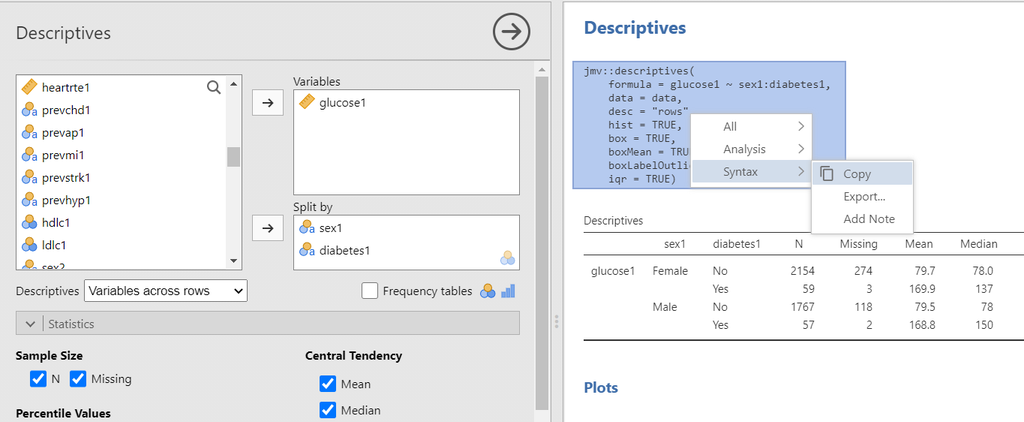

VERY IMPORTANT: make sure you change “data = data,” to “data = resample,”.

VERY IMPORTANT: make sure the order of your splitting is the way you want it. Sometimes jamovi will order it one way, but the syntax will order it another. For example, jamovi syntax mode outputs “formula = glucose1 ~ sex1:diabetes1”, but we want “formula = glucose1 ~ diabetes1:sex1”. Make sure you double check your plots to ensure it is displaying the way you would like it.

After you have done that, your block should look like this.

```
##
##  DESCRIPTIVES
##
##  Descriptives
##  ───────────────────────────────────────────────────────────────────────────────────────────────────────────────────
##                diabetes1    sex1      N       Missing    Mean      Median    SD       IQR       Minimum    Maximum
##  ───────────────────────────────────────────────────────────────────────────────────────────────────────────────────
##    glucose1    No           Female    1446        193     79.79     78.00    12.93     13.00         40        156
##                             Male      1203         72     79.62     77.00    14.01     16.50         44        163
##                Yes          Female      39          2    169.62    137.00    90.78    120.00         47        394
##                             Male        45          0    177.18    170.00    81.04     96.00         73        394
##  ───────────────────────────────────────────────────────────────────────────────────────────────────────────────────
```

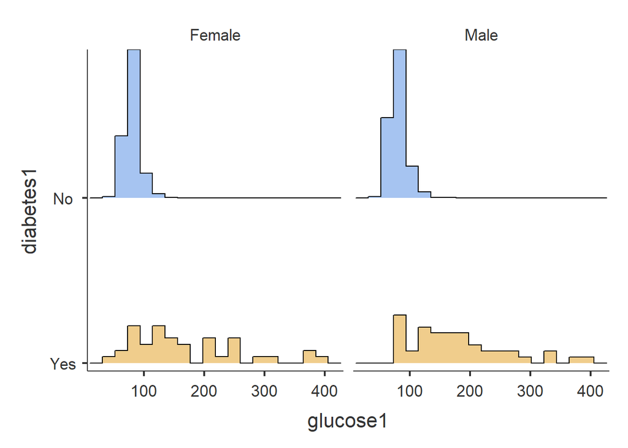

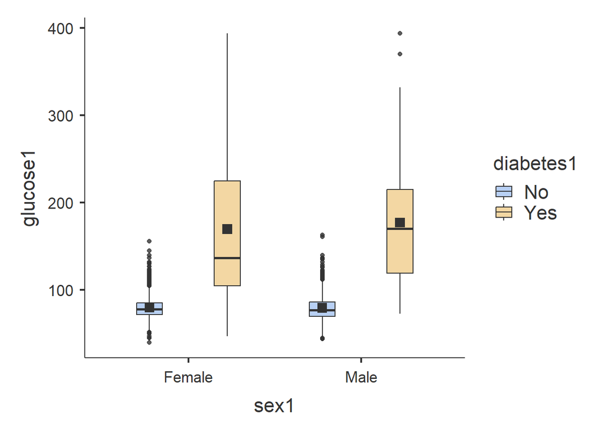

```r
  print(
    jmv::descriptives(
      formula = glucose1 ~ diabetes1:sex1,
      data = resample,
      desc = "rows",
      hist = TRUE,
      box = TRUE,
      boxMean = TRUE,
      boxLabelOutliers = FALSE,
      iqr = TRUE)
  )
```

Finally, we close the body of the for loop with “}”. The complete loop should look like this.

```r
for(i in students) {

  resample = data[sample(1:nrow(data), 3000, replace = FALSE), ]
  write.csv(resample, file = paste(outPut, "FHS sample - ", i,".csv", sep =""), row.names = FALSE)

  print(i)
  print(
    jmv::descriptives(
      formula = glucose1 ~ diabetes1:sex1,
      data = resample,
      desc = "rows",
      hist = TRUE,
      box = TRUE,
      boxMean = TRUE,
      boxLabelOutliers = FALSE,
      iqr = TRUE)
  )
}
```

In the end, your entire R code should look like this, with your particular file paths specified.

```r
options(digits=4)
library(jmv)

data = read.csv('C:\\Users\\faculty\\OneDrive - Edward Waters College\\Work\\EWC\\Professional Development\\Math Mini-Conference\\2024\\fhs sample.csv')

outPut = 'C:\\Users\\faculty\\OneDrive - Edward Waters College\\Work\\EWC\\Professional Development\\Math Mini-Conference\\2024\\Data - FHS\\'

roster = read.csv('C:\\Users\\faculty\\OneDrive - Edward Waters College\\Work\\EWC\\Professional Development\\Math Mini-Conference\\2024\\section-rosters_STA-2023-02_8_28_2023_2_37 PM.csv')
students = roster$Student.Name

for(i in students) {

  resample = data[sample(1:nrow(data), 3000, replace = FALSE), ]
  write.csv(resample, file = paste(outPut, "FHS sample - ", i,".csv", sep =""), row.names = FALSE)

  print(i)
  print(
    jmv::descriptives(
      formula = glucose1 ~ diabetes1:sex1,
      data = resample,
      desc = "rows",
      hist = TRUE,
      box = TRUE,
      boxMean = TRUE,
      boxLabelOutliers = FALSE,
      iqr = TRUE)
  )
}
```

When your R Markdown file is complete, press “Knit”. It will take around 45 seconds to execute. Once it is done, you will see all of the student data sets stored in the folder “Data - FHS” and your working folder will contain the answer key as an HTML file named “FHS - answer key”, the title you specified when you created the R Markdown file.